# COMPACTION - ScienceDirect

[figure not shown]

## Outline

1. Introduction
2. Factors and Processes Affecting Distribution and Intensity of Compaction
3. Effects on Soil Physical and Mechanical Properties
4. Compaction in Crop Production
5. Modeling of Crop Responses to Soil Compaction
6. Effects on Environmental Components
7. Techniques for the Reduction of Compaction
8. Amelioration of Compacted Soils
9. See also:
10. Further Reading

## Cited By (14)

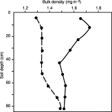

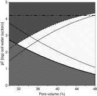

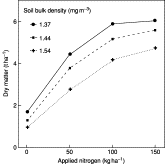

## [Encyclopedia of Soils in the Environment](https://www.sciencedirect.com/science/referenceworks/9780123485304)

2005, Pages 285-293

# COMPACTION

[J.J.H.van den Akker](https://www.sciencedirect.com/science/article/pii/B0123485304002484?via%3Dihub#!)[B.Soane](https://www.sciencedirect.com/science/article/pii/B0123485304002484?via%3Dihub#!)

https://doi.org/10.1016/B0-12-348530-4/00248-4[Get rights and content](https://s100.copyright.com/AppDispatchServlet?publisherName=ELS&contentID=B0123485304002484&orderBeanReset=true)

## First page preview

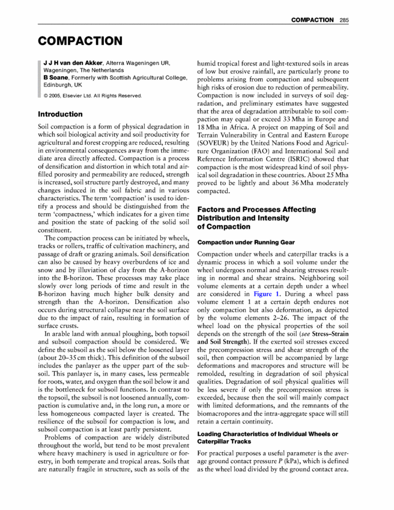

## Cited by (14)

### Groundwater dependent ecosystems in coastal Mediterranean regions: Characterization, challenges and management for their protection

- 2020, Water Research

### Evolution of soil pores and their characteristics in a siliceous and calcareous proglacial area

- 2019, Catena

  Citation Excerpt :

  It is known that land use may cause soil compaction. Macropores (>0.05 mm in diameter), through which roots can generally proliferate readily, are much reduced in compacted soil (van den Akker and Soane, 2005). The maximum graph number and the maximum graph length gave inconsistent results (Fig. 7e,f).

### Estimation of wind-driven soil erosion of a loess-like sediment and its implications for the occurrence of archaeological surface and subsurface finds – An example from the environs of Corneşti-Iarcuri, western Romania

- 2017, Journal of Archaeological Science: Reports

  Citation Excerpt :

  The analysis of the subsurface compaction along profiles crossing selected field paths revealed that in all cases the highest compaction values are found in the area of the field paths (Fig. 7). This shows that the pressure applied by vehicles, humans and animals repeatedly using the field paths causes a substantial increase in subsurface compactness in comparison to the surrounding agricultural fields (van den Akker and Soane, 2005). The increased subsurface compactness causes an increased strength of the material (van den Akker and Soane, 2005) and thus prevents wind erosion and the generation of dust, most likely even during severe windstorms (Pye, 1987).

### Assessing and predicting Compaction on Agriculturally Important Soils in Trinidad

- 2006, Biosystems Engineering

### A Review on the Effect of Soil Compaction and its Management for Sustainable Crop Production

- 2021, Journal of Biosystems Engineering

### Design and Development of a Tracked Robot to Increase Bulk Density of Flax Fibers

- 2021, Journal of Mechanisms and Robotics

Copyright © 2005 Elsevier Ltd. All rights reserved.

### Soil precompression stress, penetration resistance and crop yields in relation to differently-trafficked, temperate-region sandy loam soils

- Soil and Tillage Research, Volume 163, 2016, pp. 298-308

### Feedbacks between soil penetration resistance, root architecture and water uptake limit water accessibility and crop growth – A vicious circle

- Science of The Total Environment, Volume 626, 2018, pp. 1026-1035

### Impact of potential bio-subsoilers on pore network of a severely compacted subsoil

- Geoderma, Volume 363, 2020, Article 114154

Citations

- Citation Indexes: 14

Captures

- Readers: 39

[figure not shown]

[figure not shown]